# Abstract

Sorry, Iceland.

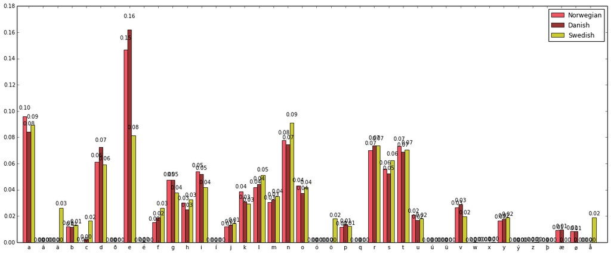

```
Distance between Norwegian and Danish: 0.0269859920538
Distance between Norwegian and Swedish: 0.083408639489
Distance between Danish and Swedish: 0.0964930218355
```

```python
letterPlot([markens_p,opdager_p,samlade_p],['#ED2939','#800000','y'],['Norwegian','Danish','Swedish'])
print "Distance between Norwegian and Danish: " + str(distance(markens_p,opdager_p))
print "Distance between Norwegian and Swedish: " + str(distance(markens_p,samlade_p))
print "Distance between Danish and Swedish: " + str(distance(opdager_p,samlade_p))
```

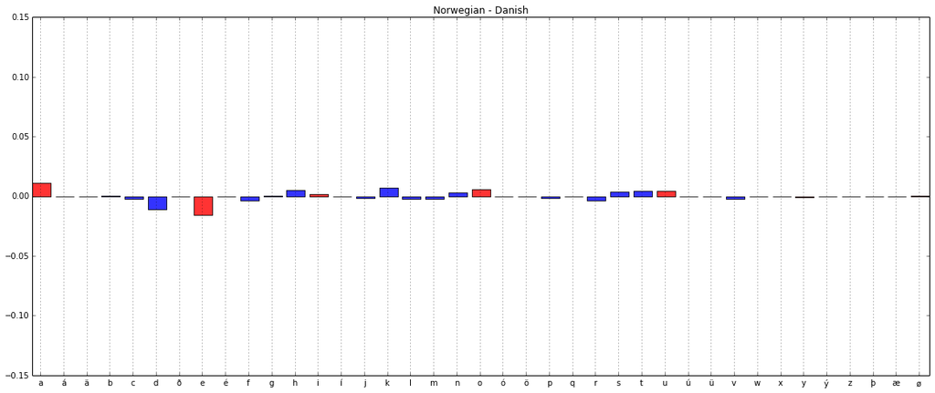

```python
differencePlot(markens_p,opdager_p,'Norwegian','Danish')
```

That's better. Now we can see that Norwegian and Danish are actually quite close - turns out they use the same alphabet. According to our `distance` function, they're actually closer to each other than Dutch is to Afrikaans, and also closer than Middle English is to English. This prompted further investigation, during which I discovered that there are in fact **two** official written standards for Norway - [Bokmål](http://en.wikipedia.org/wiki/Bokm%C3%A5l) and Nynorsk - the former being far more commonly used, and being derived from Danish. Thus we can see why Danish and Norwegian are so close - not only do they use the same alphabet, but they practically use the same language! Swedish is also relatively close to both Danish and Norwegian, but Sweden's lack of æ & ø and use of å, ä & ö definitely set it apart.

Side note: [here's how Denmark, Norway and Sweden perceive each other's languages](http://satwcomic.com/language-lesson).

Now let's go back to poor Iceland - don't want it to feel left out.

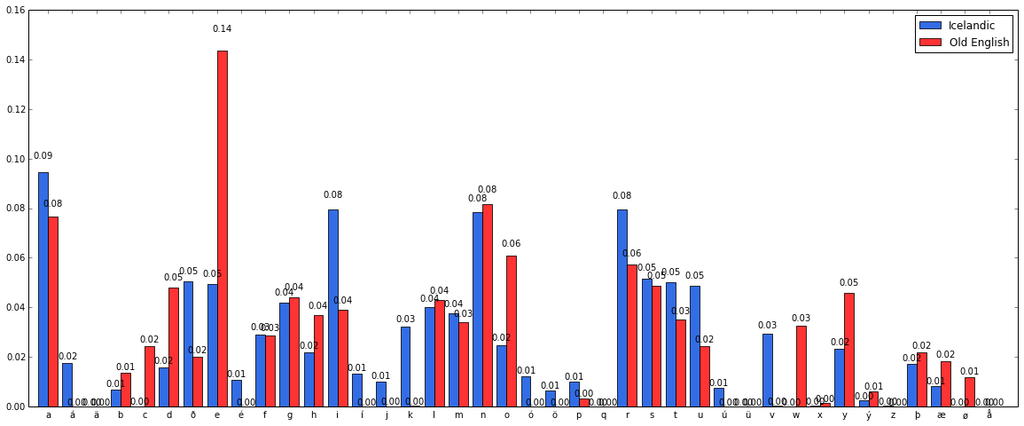

```
Distance between Icelandic and Old English: 0.145145606581
Distance between Icelandic and Danish: 0.149672560304
```

```python
letterPlot([saefarinn_p,beowulf_p],['#0048E0','r'],['Icelandic','Old English'])
print "Distance between Icelandic and Old English: " + str(distance(saefarinn_p,beowulf_p))
print "Distance between Icelandic and Danish: " + str(distance(saefarinn_p,opdager_p))
```

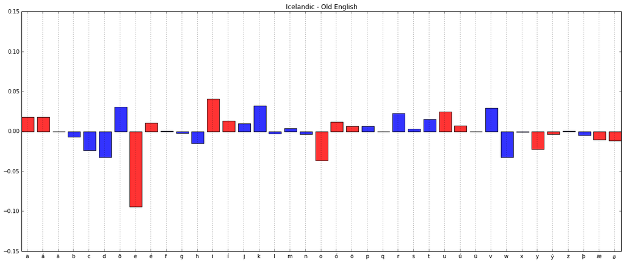

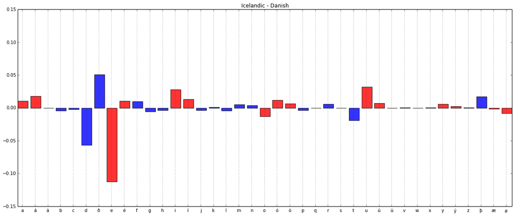

```python
differencePlot(saefarinn_p,beowulf_p,'Icelandic','Old English')
differencePlot(saefarinn_p,opdager_p,'Icelandic','Danish')
```

Looks like Icelandic is roughly as far removed from Danish as it from Old English! I suppose living on an island away from the rest of the Nordic countries, and being a country which has been obsessed with keeping its language pure [for the last several hundred years](http://en.wikipedia.org/wiki/Linguistic_purism_in_Icelandic) can have that effect.

Finally, let's have a look at what letters are most common for each language:

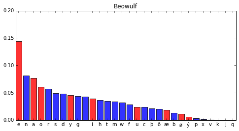

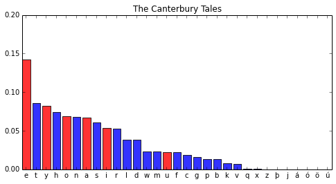

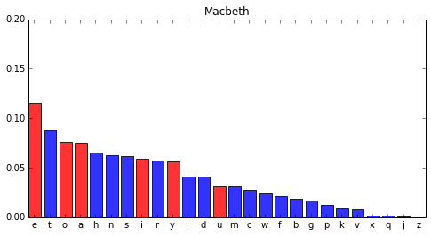

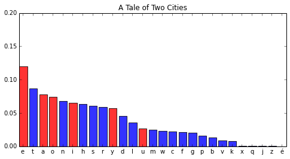

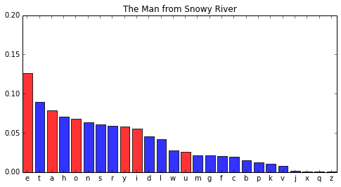

```python
#English
sortedFrequency(beowulf_p,'Beowulf')
sortedFrequency(canterbury_p,'The Canterbury Tales')
sortedFrequency(macbeth_p,'Macbeth')
sortedFrequency(taleOfTwo_p,'A Tale of Two Cities')
sortedFrequency(snowy_p,'The Man from Snowy River')
```

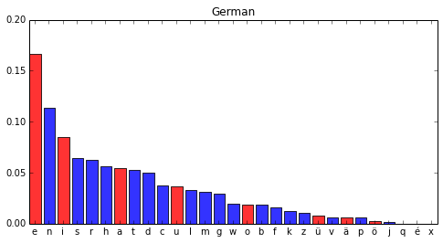

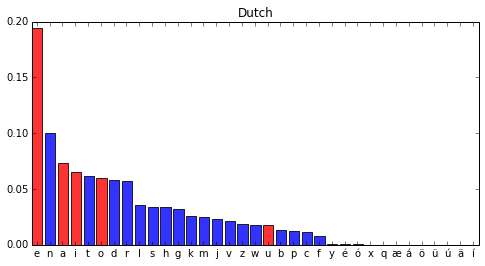

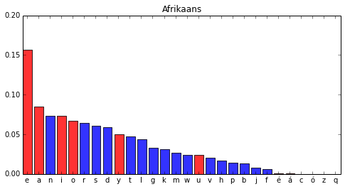

```python
#Other West Germanic
sortedFrequency(betrachtung_p,'German')
sortedFrequency(camera_p,'Dutch')
sortedFrequency(digters_p,'Afrikaans')
```

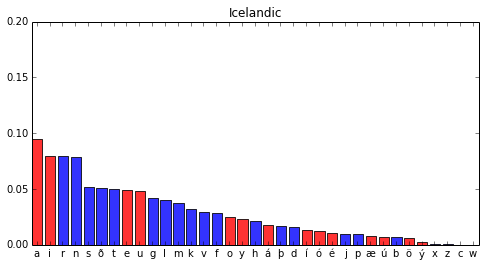

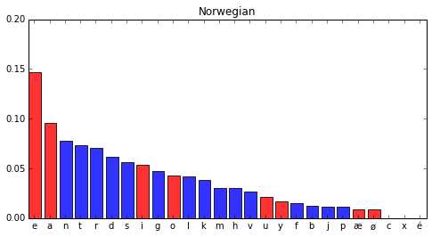

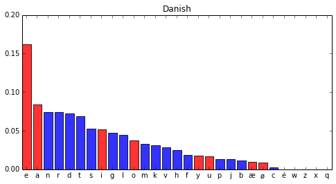

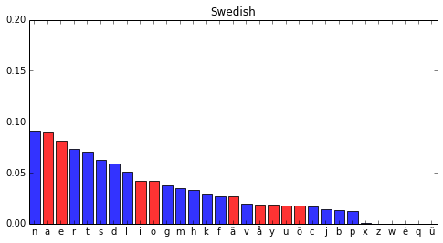

```python
#North Germanic
sortedFrequency(saefarinn_p,'Icelandic')
sortedFrequency(markens_p,'Norwegian')
sortedFrequency(opdager_p,'Danish')
sortedFrequency(samlade_p,'Swedish')
```

For the remaining West Germanic languages, German and Dutch both had N as their second most frequent letter; third most for Afrikaans. Strangely enough, Dutch & Afrikaans both have E, A and N in the top 3, as do the Continental Scandinavian languages.

For the Continental Scandinavian languages, E, A and N were the most frequent - Danish and Norwegian are again almost identical, but Swedish stands out as it is the only language listed with a consonant as the most frequent. This could be due to Swedish using two other 'a' characters: ä and å - if these were all counted as 'a', then A would be the most frequent.

# 5. Results/Insights

Discuss any non-trivial result or insight into the problem stemming from your analysis.

**Create as many code, markdown and raw cells as needed**

In this report, I was able to display some of the differences between the various Germanic languages both numerically and graphically, as well as account for some of these differences. I was able to see quite clearly some of the more prominent differences and speculate the reasons behind them.

I was also able to see mathematically how close languages are - the Modern English texts all had a distance of less than 0.025 from each other, and the distance of ~0.03 between Danish & Norwegian is what prompted me to look into the relationship between them and discover why this was the case.

The distance of ~0.04 between Middle and Modern English was surprising - they appeared to be closer together than I expected; certainly closer together than between Dutch & Afrikaans, which I was expecting to be slightly closer together.

Distances of ~0.08, ~0.09 seemed to indicate a reasonably strong relationship between 2 languages, as seen between German & Dutch, Dutch & Afrikaans, and Norwegian/Danish & Swedish. With more texts and across other language families (i.e. other than Germanic, such as Romance languages, etc.), this could be different; however, based on the data analysed, this seemed to hold true.

The distance and clear differences between Icelandic and the other languages was also rather striking, and served to show the developmental difference between a geographically isolated country and countries which would have had a high amount of interaction with each other (be it through trading, being neighbouring countries, and so forth).

Overall, whilst the data used was relatively limited (in that I used 1 text for most of the languages, and of differing lengths), there were still some interesting insights to be gained.

# 6. In hindsight...

In this section you should reflect on your work and what you've learned. In particular you should include:

```
- a discussion of the most challenging aspect of the data analysis and if/how you overcame the challenge.
- a discussion of any programming technique and/or reference you found particularly useful or helpful for your project.
- an assessment of the outcome of the study in relation to the original goals (i.e., have the goals been reached, or did you have to reassess the goals during the project, and if so why?).
- a discussion of what new, or surprising knowledge or insight into the problem you've gained by conducting the study.
- a discussion of whether you would approach the problem differently if given an opportunity to redo the work, and any advice they would give to someone who would want to work on a similar problem.
- a discussion of how your analysis could be improved or extended in future work.
```

Challenges:

- Unicode.
- Trying to generalise functions (such as `letterPlot` and `textClean`) instead of hardcoding them was challenging, but worth the effort, and it certainly makes the notebook a lot tidier than it would otherwise be. For `letterPlot`, there was a lot of trial and error to find the right parameters to make it work. With `textClean`, I was hesitant at first because I wasn't sure how to pass a variable to make a filepath. Of course, Python is beautiful in its simplicity and lets me just do it intuitively; there was no need for me to overcomplicate things.
- Unicode.

Techniques & references:

- A lot of the string operations we did early on in the course were useful - in fact, it was after doing one of the strings assignments we had for homework that I stopped and thought, "I wonder if I can get a nice little graph of the letter frequency of this..."
- The lesson on unicode proved to be quite useful - there was a lot of consulting that notebook, python documentation and stackoverflow in order to figure out how to get the unicode to work.
- Matplotlib - for my `letterPlot`, I adapted [this example](http://matplotlib.org/examples/api/barchart_demo.html) from the matplotlib website, and played around with different things to get it to do what I wanted.

Assessment of outcome:

- I believe I've successfully achieved the goals that I set - the graphs certainly displayed any prominent differences and similarities, and a few of these were certainly able to be accounted for; perhaps somebody studying linguistics would be able to further explain some more of these.

New insights:

- When I first began, I wasn't certain about the extent to which I'd be able to extract meaningful data to be analysed, in terms of applying these mathematical methods to different groups of languages. However, I was pleasantly surprised to see that such methods worked reasonably well, and as has been seen, insights can be gathered from these.
- It would appear that the `distance` function works reasonably well in measuring how close languages are, up to a point; distances of above ~0.1 started to give less information about relatedness, and it would be interesting to see how this plays out between wider language families.
- The letter E is the most used letter not just in English, but in most of the Germanic languages, often by a significant margin.

Improvements or Extensions:

- This project could easily be adapted to other language families, such as the Romance or Slavic languages, as well as more in-depth looks at different time periods for a specific language. Other extensions could include a look at regional dialects of a language, such as comparing American English to Australian English and English proper.
- Related to the above point: a meta-project could compare high-level language families with each other, e.g. comparing Germanic to Italic to Celtic, and so forth.
- The scope of this project was relatively small - I only used 1 text for most of the languages, and it would definitely be better to have a broader range of texts.
- Another extension would be to compare specific letters or even letter combinations, such as looking solely at vowel distribution, or comparing digraphs such as 'TH', etc. across the different languages.